# NYPD: Time and Space of Shooting Incidents

## Data Description

The data for this project is from the New York City Open Data portal.  
The dataset is the NYPD Shooting Incident Data (Historic) and contains information on shooting incidents in New York City.  
The data is available in CSV format and can be downloaded from the following link:  
https://catalog.data.gov/dataset/nypd-shooting-incident-data-historic

Detailed description of the dataset was provided by the NYPD:  
Details on data description: https://data.cityofnewyork.us/Public-Safety/NYPD-Shooting-Incident-Data-Historic-/833y-fsy8/about_data

```r
suppressPackageStartupMessages(library(ggplot2))
suppressPackageStartupMessages(library(tidyr))
suppressPackageStartupMessages(library(lubridate))
suppressPackageStartupMessages(library(dplyr))
```

### Data Import and Structure

```r
df <- read.csv('https://data.cityofnewyork.us/api/views/833y-fsy8/rows.csv?accessType=DOWNLOAD')
head(df, 2)
```

```
##   INCIDENT_KEY OCCUR_DATE OCCUR_TIME     BORO LOC_OF_OCCUR_DESC PRECINCT
## 1    231974218 08/09/2021   01:06:00    BRONX                         40
## 2    177934247 04/07/2018   19:48:00 BROOKLYN                         79
##   JURISDICTION_CODE LOC_CLASSFCTN_DESC LOCATION_DESC STATISTICAL_MURDER_FLAG
## 1                 0                                                    false
## 2                 0                                                     true
##   PERP_AGE_GROUP PERP_SEX      PERP_RACE VIC_AGE_GROUP VIC_SEX VIC_RACE
## 1                                                18-24       M    BLACK
## 2          25-44        M WHITE HISPANIC         25-44       M    BLACK
##   X_COORD_CD Y_COORD_CD Latitude Longitude
## 1    1006343   234270.0 40.80967 -73.92019
## 2    1000083   189064.7 40.68561 -73.94291
##                                         Lon_Lat
## 1  POINT (-73.92019278899994 40.80967347200004)
## 2 POINT (-73.94291302299996 40.685609672000055)
```

```r
names(df) <- tolower(names(df))
str(df)
```

```
## 'data.frame':    28562 obs. of  21 variables:
##  $ incident_key           : int  231974218 177934247 255028563 25384540 72616285 85875439 79780323 85744504 142324890 152868707 ...
##  $ occur_date             : chr  "08/09/2021" "04/07/2018" "12/02/2022" "11/19/2006" ...
##  $ occur_time             : chr  "01:06:00" "19:48:00" "22:57:00" "01:50:00" ...
##  $ boro                   : chr  "BRONX" "BROOKLYN" "BRONX" "BROOKLYN" ...
##  $ loc_of_occur_desc      : chr  "" "" "OUTSIDE" "" ...
##  $ precinct               : int  40 79 47 66 46 42 71 69 75 69 ...
##  $ jurisdiction_code      : int  0 0 0 0 0 2 0 2 0 0 ...
##  $ loc_classfctn_desc     : chr  "" "" "STREET" "" ...
##  $ location_desc          : chr  "" "" "GROCERY/BODEGA" "PVT HOUSE" ...
##  $ statistical_murder_flag: chr  "false" "true" "false" "true" ...
##  $ perp_age_group         : chr  "" "25-44" "(null)" "UNKNOWN" ...
##  $ perp_sex               : chr  "" "M" "(null)" "U" ...
##  $ perp_race              : chr  "" "WHITE HISPANIC" "(null)" "UNKNOWN" ...
##  $ vic_age_group          : chr  "18-24" "25-44" "25-44" "18-24" ...
##  $ vic_sex                : chr  "M" "M" "M" "M" ...
##  $ vic_race               : chr  "BLACK" "BLACK" "BLACK" "BLACK" ...
##  $ x_coord_cd             : num  1006343 1000083 1020691 985107 1009854 ...
##  $ y_coord_cd             : num  234270 189065 257125 173350 247503 ...
##  $ latitude               : num  40.8 40.7 40.9 40.6 40.8 ...
##  $ longitude              : num  -73.9 -73.9 -73.9 -74 -73.9 ...
##  $ lon_lat                : chr  "POINT (-73.92019278899994 40.80967347200004)" "POINT (-73.94291302299996 40.685609672000055)" "POINT (-73.868233 40.872349)" "POINT (-73.99691224999998 40.642489932000046)" ...
```

| Column Name | Description | API Field Name | Data Type |
| --- | --- | --- | --- |
| INCIDENT_KEY | Randomly generated persistent ID for each arrest | incident_key | Text |
| OCCUR_DATE | Exact date of the shooting incident | occur_date | Floating Timestamp |
| OCCUR_TIME | Exact time of the shooting incident | occur_time | Text |
| BORO | Borough where the shooting incident occurred | boro | Text |
| LOC_OF_OCCUR_DESC | Location where the shooting incident occurred | loc_of_occur_desc | Text |
| PRECINCT | Precinct where the shooting incident occurred | precinct | Number |
| JURISDICTION_CODE | Jurisdiction where the shooting incident occurred. Jurisdiction codes 0(Patrol), 1(Transit) and 2(Housing) represent NYPD whilst codes 3 and more represent non NYPD jurisdictions | jurisdiction_code | Number |
| LOC_CLASSFCTN_DESC | Classification of the location where the shooting incident occurred | loc_classfctn_desc | Text |
| LOCATION_DESC | Location of the shooting incident | location_desc | Text |
| STATISTICAL_MURDER_FLAG | Shooting resulted in the victim’s death which would be counted as a murder | statistical_murder_flag | Checkbox |
| PERP_AGE_GROUP | Perpetrator’s age within a category | perp_age_group | Text |
| PERP_SEX | Perpetrator’s sex description | perp_sex | Text |
| PERP_RACE | Perpetrator’s race description | perp_race | Text |
| VIC_AGE_GROUP | Victim’s age within a category | vic_age_group | Text |
| VIC_SEX | Victim’s sex description | vic_sex | Text |
| VIC_RACE | Victim’s race description | vic_race | Text |
| X_COORD_CD | Midblock X-coordinate for New York State Plane Coordinate System, Long Island Zone, NAD 83, units feet (FIPS 3104) | x_coord_cd | Text |
| Y_COORD_CD | Midblock Y-coordinate for New York State Plane Coordinate System, Long Island Zone, NAD 83, units feet (FIPS 3104) | y_coord_cd | Text |
| Latitude | Latitude coordinate for Global Coordinate System, WGS 1984, decimal degrees (EPSG 4326) | latitude | Number |
| Longitude | Longitude coordinate for Global Coordinate System, WGS 1984, decimal degrees (EPSG 4326) | longitude | Number |
| Lon_Lat | Longitude and Latitude Coordinates for mapping | geocoded_column | Point |

## Tidy and Transforming Data

We will proceed all the columns of the dataset one by one to study them and decide what to do with them.  
The important limitation is that due to the limited size of the assignment, I would like to focus on data related to time and space of the incidents.

### Unique Identifiers, Dates, and Times

**incendent_key** a unique identifier for each incident (int)  
While it should be unique, we will check if there are any duplicates.  
There are duplicates by incident_key, as well as by key time and location.  
Thus we can assume that for each incident there are multiple records, probably related to several victims.

```r
length(unique(df$incident_key))
```

```
## [1] 22394
```

```r
sum(duplicated(df$incident_key)) # 6168
```

```
## [1] 6168
```

```r
sum(duplicated(df[c("incident_key", "occur_date", 'lon_lat', 'precinct')])) # 6168
```

```
## [1] 6168
```

```r
# full duplicates
sum(duplicated(df)) # 0
```

```
## [1] 0
```

```r
str(df)
```

```
## 'data.frame':    28562 obs. of  21 variables:
##  $ incident_key           : int  231974218 177934247 255028563 25384540 72616285 85875439 79780323 85744504 142324890 152868707 ...
##  $ occur_date             : chr  "08/09/2021" "04/07/2018" "12/02/2022" "11/19/2006" ...
##  $ occur_time             : chr  "01:06:00" "19:48:00" "22:57:00" "01:50:00" ...
##  $ boro                   : chr  "BRONX" "BROOKLYN" "BRONX" "BROOKLYN" ...
##  $ loc_of_occur_desc      : chr  "" "" "OUTSIDE" "" ...
##  $ precinct               : int  40 79 47 66 46 42 71 69 75 69 ...
##  $ jurisdiction_code      : int  0 0 0 0 0 2 0 2 0 0 ...
##  $ loc_classfctn_desc     : chr  "" "" "STREET" "" ...
##  $ location_desc          : chr  "" "" "GROCERY/BODEGA" "PVT HOUSE" ...
##  $ statistical_murder_flag: chr  "false" "true" "false" "true" ...
##  $ perp_age_group         : chr  "" "25-44" "(null)" "UNKNOWN" ...
##  $ perp_sex               : chr  "" "M" "(null)" "U" ...
##  $ perp_race              : chr  "" "WHITE HISPANIC" "(null)" "UNKNOWN" ...
##  $ vic_age_group          : chr  "18-24" "25-44" "25-44" "18-24" ...
##  $ vic_sex                : chr  "M" "M" "M" "M" ...
##  $ vic_race               : chr  "BLACK" "BLACK" "BLACK" "BLACK" ...
##  $ x_coord_cd             : num  1006343 1000083 1020691 985107 1009854 ...
##  $ y_coord_cd             : num  234270 189065 257125 173350 247503 ...
##  $ latitude               : num  40.8 40.7 40.9 40.6 40.8 ...
##  $ longitude              : num  -73.9 -73.9 -73.9 -74 -73.9 ...
##  $ lon_lat                : chr  "POINT (-73.92019278899994 40.80967347200004)" "POINT (-73.94291302299996 40.685609672000055)" "POINT (-73.868233 40.872349)" "POINT (-73.99691224999998 40.642489932000046)" ...
```

**occure_date** - character in format “MM/DD/YYYY” - we need to convert to date  
**occure_time** - character in format “HH:MM:SS” - we need to convert to time (without date)  
the detailed time of incindent may be of lesser interest, however its destribution by hour is something to be studied

```r
df$occur_date <- as.Date(df$occur_date, format = "%m/%d/%Y")

df$occur_time <- as.POSIXct(df$occur_time, format = "%H:%M:%S")
df$hour_of_occurance <- as.numeric(format(df$occur_time, "%H"))

df <- subset(df, select = -c(occur_time))
```

### Locations

**boro** character - we need to convert to factor it is the bigger area of the city

```r
length(unique(df$boro))
```

```
## [1] 5
```

```r
unique(df$boro)
```

```
## [1] "BRONX"         "BROOKLYN"      "MANHATTAN"     "QUEENS"
## [5] "STATEN ISLAND"
```

```r
sum(is.na(df$boro)) # 0
```

```
## [1] 0
```

```r
df$boro <- factor(df$boro)
```

**loc_of_occur_desc** character - there are to many missing values - remove this data

```r
length(unique(df$loc_of_occur_desc))
```

```
## [1] 3
```

```r
unique(df$loc_of_occur_desc)
```

```
## [1] ""        "OUTSIDE" "INSIDE"
```

```r
df$loc_of_occur_desc <- factor(df$loc_of_occur_desc)

# count number of rows for each loc_of_occur_desc
df %>%
  group_by(loc_of_occur_desc) %>%
  summarise(count = n()) %>%
  arrange(desc(count)) %>%
  head(10)
```

```
## # A tibble: 3 × 2
##   loc_of_occur_desc count
##   <fct>             <int>
## 1 ""                25596
## 2 "OUTSIDE"          2506
## 3 "INSIDE"            460
```

```r
# delete this column
df <- subset(df, select = -c(loc_of_occur_desc))
```

**precinct** integer - but it is factor by nature - we would need to convert it to factor  
However, this is very detailed location information, which can be skipped for this analysis. **jurisdiction_code** integer - but it is factor by nature - we need to convert to factor

```r
summary(df$precinct)
```

```
##    Min. 1st Qu.  Median    Mean 3rd Qu.    Max.
##     1.0    44.0    67.0    65.5    81.0   123.0
```

```r
df <- subset(df, select = -c(precinct))

length(unique(df$jurisdiction_code))
```

```
## [1] 4
```

```r
unique(df$jurisdiction_code)
```

```
## [1]  0  2  1 NA
```

```r
df$jurisdiction_code <- factor(df$jurisdiction_code)
sum(is.na(df$jurisdiction_code))
```

```
## [1] 2
```

**loc_classfctn_desc** character - we would need to convert to factor the location classification, however there are to many missing values  
**location_desc** too many missing values - remove this data  
**coordinates**  
We will drop all the coordinates (x_coord_cd, y_coord_cd, latitude, longitude, lon_lat)  
Analysis of detailed geographical data is out of scope of this project.

```r
length(unique(df$loc_classfctn_desc))
```

```
## [1] 11
```

```r
unique(df$loc_classfctn_desc)
```

```
##  [1] ""            "STREET"      "OTHER"       "PLAYGROUND"  "TRANSIT"
##  [6] "HOUSING"     "COMMERCIAL"  "DWELLING"    "VEHICLE"     "PARKING LOT"
## [11] "(null)"
```

```r
# (null) and empty string should be treated as missing values
df$loc_classfctn_desc[df$loc_classfctn_desc == "(null)" | df$loc_classfctn_desc == ""] <- NA
df$loc_classfctn_desc <- factor(df$loc_classfctn_desc)

# count all the data for this one for each factor
df %>%
  group_by(loc_classfctn_desc) %>%
  summarise(count = n()) %>%
  arrange(desc(count)) %>%
  head(10)
```

```
## # A tibble: 10 × 2
##    loc_classfctn_desc count
##    <fct>              <int>
##  1 <NA>               25598
##  2 STREET              1886
##  3 HOUSING              460
##  4 DWELLING             243
##  5 COMMERCIAL           208
##  6 OTHER                 59
##  7 PLAYGROUND            41
##  8 VEHICLE               29
##  9 TRANSIT               23
## 10 PARKING LOT           15
```

```r
df <- subset(df, select = -c(loc_classfctn_desc))

length(unique(df$location_desc))
```

```
## [1] 41
```

```r
unique(df$location_desc)
```

```
##  [1] ""                          "GROCERY/BODEGA"
##  [3] "PVT HOUSE"                 "MULTI DWELL - APT BUILD"
##  [5] "MULTI DWELL - PUBLIC HOUS" "(null)"
##  [7] "BAR/NIGHT CLUB"            "COMMERCIAL BLDG"
##  [9] "FAST FOOD"                 "HOSPITAL"
## [11] "BEAUTY/NAIL SALON"         "LIQUOR STORE"
## [13] "CHAIN STORE"               "RESTAURANT/DINER"
## [15] "SMALL MERCHANT"            "GAS STATION"
## [17] "JEWELRY STORE"             "GYM/FITNESS FACILITY"
## [19] "STORE UNCLASSIFIED"        "SOCIAL CLUB/POLICY LOCATI"
## [21] "DRY CLEANER/LAUNDRY"       "NONE"
## [23] "VIDEO STORE"               "SUPERMARKET"
## [25] "VARIETY STORE"             "FACTORY/WAREHOUSE"
## [27] "CLOTHING BOUTIQUE"         "SHOE STORE"
## [29] "HOTEL/MOTEL"               "CANDY STORE"
## [31] "DEPT STORE"                "BANK"
## [33] "TELECOMM. STORE"           "DRUG STORE"
## [35] "LOAN COMPANY"              "CHECK CASH"
## [37] "SCHOOL"                    "STORAGE FACILITY"
## [39] "PHOTO/COPY STORE"          "ATM"
## [41] "DOCTOR/DENTIST"
```

```r
df <- subset(df, select = -c(location_desc))

# drop all the coordinates
df <- subset(df, select = -c(x_coord_cd, y_coord_cd, latitude, longitude, lon_lat))
```

### Other data fields

Information on the age, sex, and race of the people involved is skipped in this analysis.  
While I found this an extremely important topic, I believe it will be studied in other work.  
Also, I do not have a background in US life, and my bias is that I am out of context.

**statistical_murder_flag** we need to bring it back to bool

```r
# Drop columns per_age_group, perp_sex, perp_race, vic_age_group, vic_sex, vic_race
df <- subset(df, select = -c(perp_age_group, perp_sex, perp_race, vic_age_group, vic_sex, vic_race))

length(unique(df$statistical_murder_flag))
```

```
## [1] 2
```

```r
unique(df$statistical_murder_flag)
```

```
## [1] "false" "true"
```

```r
# bring it to bool
df$statistical_murder_flag <- as.logical(df$statistical_murder_flag)
```

```r
str(df)
```

```
## 'data.frame':    28562 obs. of  6 variables:
##  $ incident_key           : int  231974218 177934247 255028563 25384540 72616285 85875439 79780323 85744504 142324890 152868707 ...
##  $ occur_date             : Date, format: "2021-08-09" "2018-04-07" ...
##  $ boro                   : Factor w/ 5 levels "BRONX","BROOKLYN",..: 1 2 1 2 1 1 2 2 2 2 ...
##  $ jurisdiction_code      : Factor w/ 3 levels "0","1","2": 1 1 1 1 1 3 1 3 1 1 ...
##  $ statistical_murder_flag: logi  FALSE TRUE FALSE TRUE TRUE FALSE ...
##  $ hour_of_occurance      : num  1 19 22 1 1 21 22 23 15 15 ...
```

## Vusyalising, Analyzing, and Modeling Data

### Data and time related analysis

At first, we will study how the number of incidents depends on time.

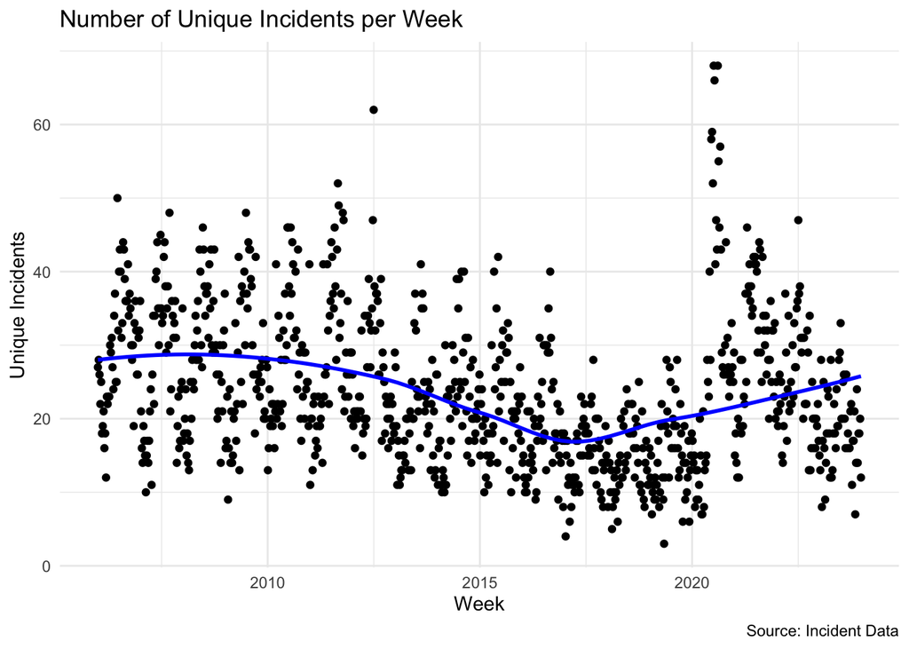

```r
# First, let's calculate unique incidents by week
df_weekly <- df %>%
  mutate(week = floor_date(occur_date, "week")) %>%
  group_by(week) %>%
  summarize(unique_incidents = n_distinct(incident_key))

# Scatter plot of unique incidents by week
p1 <- ggplot(df_weekly, aes(x = week, y = unique_incidents)) +
  geom_point() +
  geom_smooth(method = "loess", se = FALSE, color = "blue") +
  labs(
    title = "Number of Unique Incidents per Week",
    x = "Week",
    y = "Unique Incidents",
    caption = "Source: Incident Data"
  ) +
  theme_minimal()

print(p1)
```

First of all, **the overall number of incindents does not clearly decline over time**.  
While there was decline in mid 2010s, it did not become a trend.  
May be COVID-19 pandemic had an impact on the number of incidents - which spiked at 2020 and 2021.  
In future years it will be interesting to see if the number of incidents will decline again.  
There is clearly visible seasonability of the incidents, which we will study in more detail later.

```r
# Calculate summary statistics
total_unique_incidents <- n_distinct(df$incident_key)
avg_weekly_incidents <- mean(df_weekly$unique_incidents)

# Print the summary statistics
cat("Total number of unique incidents:", total_unique_incidents, "\n")
```

```
## Total number of unique incidents: 22394
```

```r
cat("Average number of unique incidents per week:", round(avg_weekly_incidents, 2), "\n")
```

```
## Average number of unique incidents per week: 23.85
```

Astonishingly, the average number of incidents per week is 24.  
Which is **more than 3 shootings per day**.

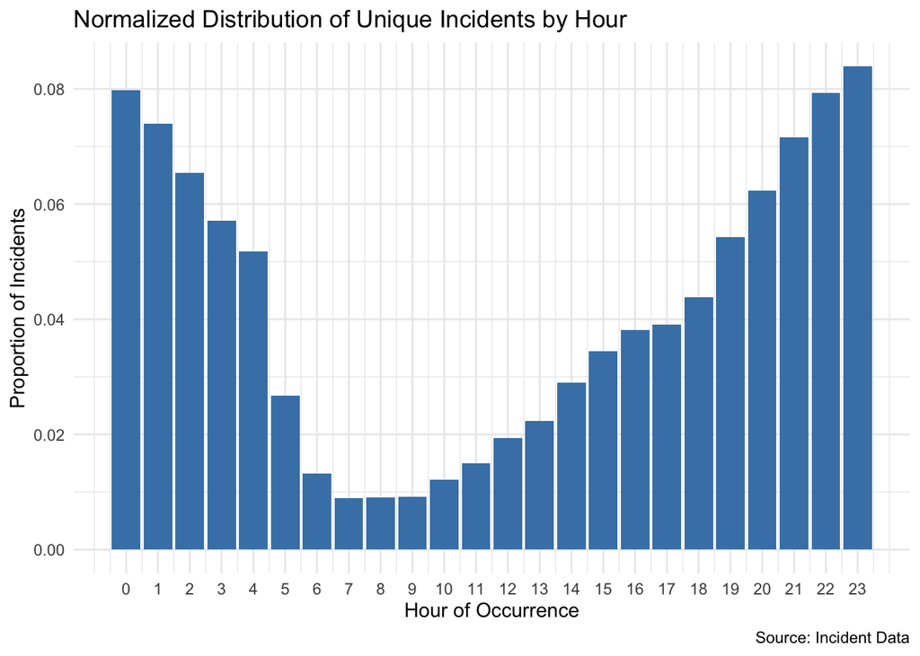

```r
# Calculate unique incidents by hour (normalized)
df_hourly <- df %>%
  group_by(hour_of_occurance) %>%
  summarize(
    unique_incidents = n_distinct(incident_key),
    .groups = "drop"
  ) %>%
  mutate(normalized_incidents = unique_incidents / sum(unique_incidents))

# Bar chart of unique incidents by hour (normalized)
p3 <- ggplot(df_hourly, aes(x = hour_of_occurance, y = normalized_incidents)) +
  geom_bar(stat = "identity", fill = "steelblue") +
  labs(
    title = "Normalized Distribution of Unique Incidents by Hour",
    x = "Hour of Occurrence",
    y = "Proportion of Incidents",
    caption = "Source: Incident Data"
  ) +
  scale_x_continuous(breaks = 0:23) +
  theme_minimal()

print(p3)
```

### Place and jurisdiction related analysis

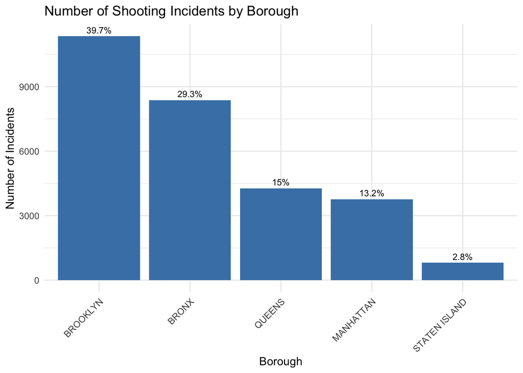

```r
boro_counts <- df %>%
  count(boro) %>%
  mutate(percentage = n/sum(n) * 100)

ggplot(boro_counts, aes(x = reorder(boro, -n), y = n)) +
  geom_bar(stat = "identity", fill = "steelblue") +
  geom_text(aes(label = paste0(round(percentage, 1), "%")),
            vjust = -0.5, size = 3) +
  labs(title = "Number of Shooting Incidents by Borough",
       x = "Borough", y = "Number of Incidents") +
  theme_minimal() +
  theme(axis.text.x = element_text(angle = 45, hjust = 1))
```

**Brooklyn** is the most dangerous borough with 40% of all incidents.  
**Staten Island** is the safest borough with only 3% of all incidents.  
It would be important to compare the number of incidents with the population of each borough.

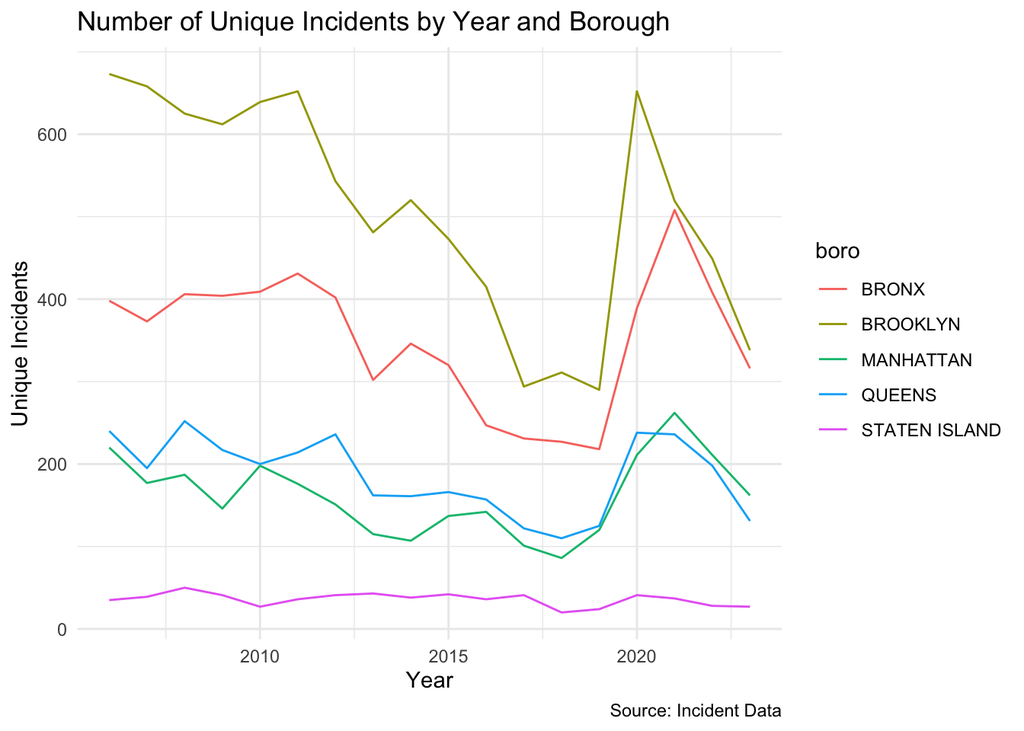

```r
df_boro_yearly <- df %>%
  mutate(year = year(occur_date)) %>%
  group_by(year, boro) %>%
  summarize(unique_incidents = n_distinct(incident_key), .groups = "drop")


ggplot(df_boro_yearly, aes(x = year, y = unique_incidents, color = boro)) +
  geom_line() +
  labs(
    title = "Number of Unique Incidents by Year and Borough",
    x = "Year",
    y = "Unique Incidents",
    caption = "Source: Incident Data"
  ) +
  theme_minimal()
```

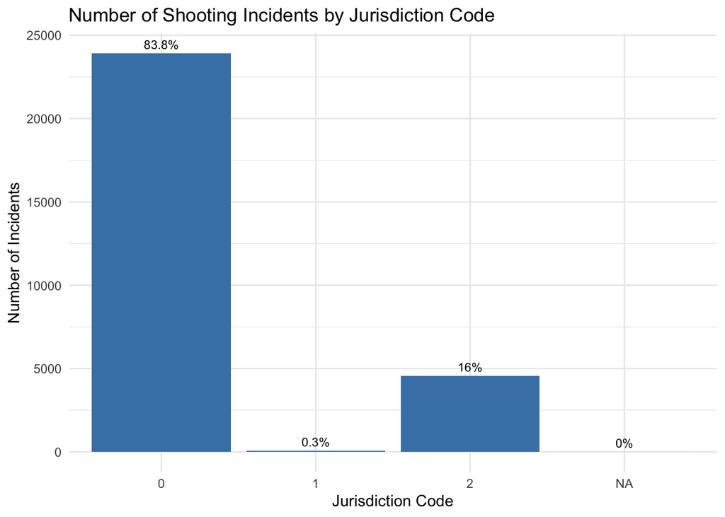

```r
jurisdiction_counts <- df %>%
  count(jurisdiction_code) %>%
  mutate(percentage = n/sum(n) * 100)

ggplot(jurisdiction_counts, aes(x = as.factor(jurisdiction_code), y = n)) +
  geom_bar(stat = "identity", fill = "steelblue") +
  geom_text(aes(label = paste0(round(percentage, 1), "%")),
            vjust = -0.5, size = 3) +
  labs(title = "Number of Shooting Incidents by Jurisdiction Code",
       x = "Jurisdiction Code", y = "Number of Incidents") +
  theme_minimal()
```

Jurisdiction codes 0(Patrol), 1(Transit) and 2(Housing).  
Clearly the majority of incidents are in the Patrol jurisdiction with over 80$% of all incidents.

## Modeling Data

We will focus our attnetion on time-related dependancies for this report.  
First with relation to hour of the day.

```r
df_hourly <- df %>%
  group_by(hour_of_occurance) %>%
  summarize(unique_incidents = n_distinct(incident_key), .groups = "drop")


model_1 <- lm(unique_incidents ~ hour_of_occurance, data = df_hourly)
summary(model_1)
```

```
##
## Call:
## lm(formula = unique_incidents ~ hour_of_occurance, data = df_hourly)
##
## Residuals:
##    Min     1Q Median     3Q    Max
## -689.8 -518.2 -143.2  487.4 1024.5
##
## Coefficients:
##                   Estimate Std. Error t value Pr(>|t|)
## (Intercept)         761.49     227.44   3.348  0.00291 **
## hour_of_occurance    14.92      16.94   0.881  0.38807
## ---
## Signif. codes:  0 '***' 0.001 '**' 0.01 '*' 0.05 '.' 0.1 ' ' 1
##
## Residual standard error: 574.6 on 22 degrees of freedom
## Multiple R-squared:  0.03405,    Adjusted R-squared:  -0.009862
## F-statistic: 0.7754 on 1 and 22 DF,  p-value: 0.3881
```

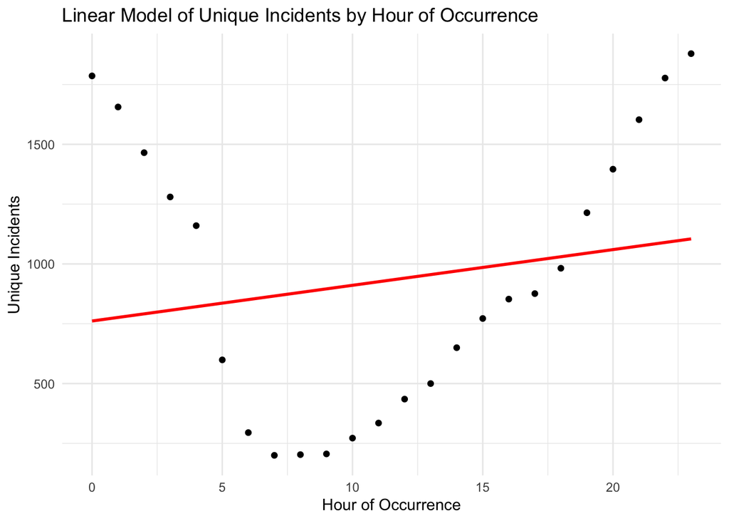

```r
ggplot(df_hourly, aes(x = hour_of_occurance, y = unique_incidents)) +
  geom_point() +
  geom_smooth(method = "lm", se = FALSE, color = "red") +
  labs(
    title = "Linear Model of Unique Incidents by Hour of Occurrence",
    x = "Hour of Occurrence",
    y = "Unique Incidents"
  ) +
  theme_minimal()
```

The linear correlation with just hour of day is neglactble.  
However, if we take how far the hour is from midday, we can see a clear linear correlation.

```r
df_hourly$hour_from_midday <- abs(df_hourly$hour_of_occurance - 12)
model_2 <- lm(unique_incidents ~ hour_from_midday, data = df_hourly)
summary(model_2)
```

```
##
## Call:
## lm(formula = unique_incidents ~ hour_from_midday, data = df_hourly)
##
## Residuals:
##     Min      1Q  Median      3Q     Max
## -638.08  -77.76   64.99  253.81  330.78
##
## Coefficients:
##                  Estimate Std. Error t value Pr(>|t|)
## (Intercept)        104.22     120.85   0.862    0.398
## hour_from_midday   138.14      17.41   7.934 6.78e-08 ***
## ---
## Signif. codes:  0 '***' 0.001 '**' 0.01 '*' 0.05 '.' 0.1 ' ' 1
##
## Residual standard error: 297.5 on 22 degrees of freedom
## Multiple R-squared:  0.741,  Adjusted R-squared:  0.7292
## F-statistic: 62.94 on 1 and 22 DF,  p-value: 6.778e-08
```

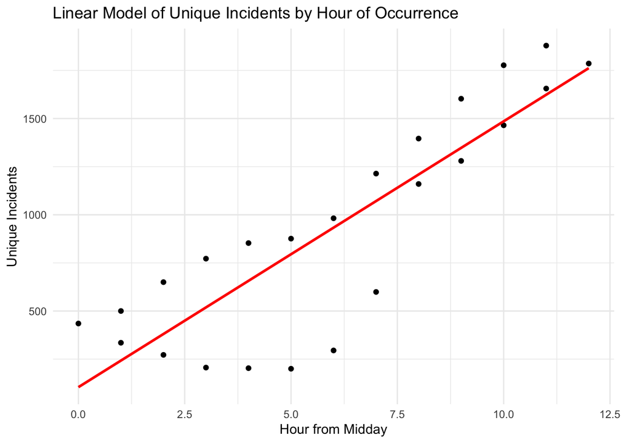

```r
# Plot the model

ggplot(df_hourly, aes(x = hour_from_midday, y = unique_incidents)) +
  geom_point() +
  geom_smooth(method = "lm", se = FALSE, color = "red") +
  labs(
    title = "Linear Model of Unique Incidents by Hour of Occurrence",
    x = "Hour from Midday",
    y = "Unique Incidents"
  ) +
  theme_minimal()
```

Another interesting aspect is seasonability on longer time scale.  
Week and month of the year.

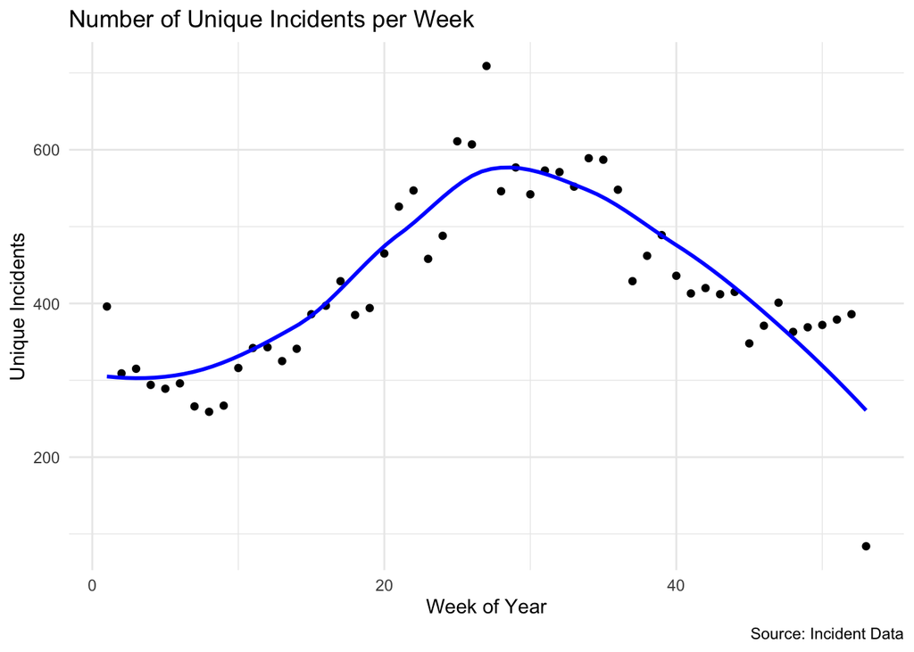

```r
df$week_of_year <- week(df$occur_date)

df_by_week <- df %>%
  group_by(week_of_year) %>%
  summarize(unique_incidents = n_distinct(incident_key), .groups = "drop")

p4 <- ggplot(df_by_week, aes(x = week_of_year, y = unique_incidents)) +
  geom_point() +
  geom_smooth(method = "loess", se = FALSE, color = "blue") +
  labs(
    title = "Number of Unique Incidents per Week",
    x = "Week of Year",
    y = "Unique Incidents",
    caption = "Source: Incident Data"
  ) +
  theme_minimal()

print(p4)
```

There is a clear correlation between the number of incidents and the week of the year.  
There is also a smaller sized dependancy likely related to week of the month.

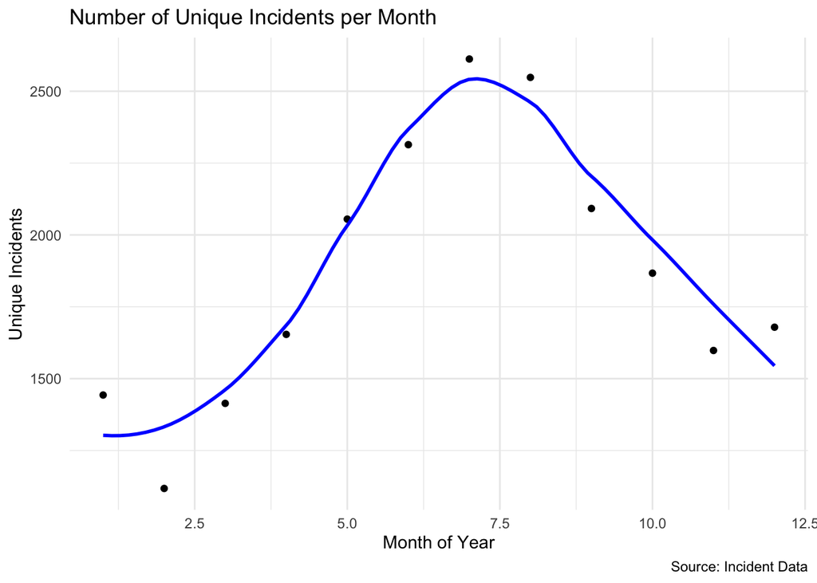

```r
df$month_of_year <- month(df$occur_date)

df_by_month <- df %>%
  group_by(month_of_year) %>%
  summarize(unique_incidents = n_distinct(incident_key), .groups = "drop")

p5 <- ggplot(df_by_month, aes(x = month_of_year, y = unique_incidents)) +
  geom_point() +
  geom_smooth(method = "loess", se = FALSE, color = "blue") +
  labs(
    title = "Number of Unique Incidents per Month",
    x = "Month of Year",
    y = "Unique Incidents",
    caption = "Source: Incident Data"
  ) +
  theme_minimal()

print(p5)
```

It is slightly smoothed for months.  
The peak is in July and August, while the lowest number of incidents is in winter.  
There is a small increase in the number of incidents around December and January.  
Probably related to holidays.

Let’s try to model the number of incendents by how far the week is from the middle of the year.

```r
mid_week <- 26
df_by_week$week_from_mid_year <- abs(df_by_week$week_of_year - mid_week)
model_3 <- lm(unique_incidents ~ week_from_mid_year, data = df_by_week)

summary(model_3)
```

```
##
## Call:
## lm(formula = unique_incidents ~ week_from_mid_year, data = df_by_week)
##
## Residuals:
##     Min      1Q  Median      3Q     Max
## -176.61  -63.22   10.93   53.05  141.90
##
## Coefficients:
##                    Estimate Std. Error t value Pr(>|t|)
## (Intercept)         578.884     20.046  28.878  < 2e-16 ***
## week_from_mid_year  -11.788      1.308  -9.015 3.92e-12 ***
## ---
## Signif. codes:  0 '***' 0.001 '**' 0.01 '*' 0.05 '.' 0.1 ' ' 1
##
## Residual standard error: 73.16 on 51 degrees of freedom
## Multiple R-squared:  0.6144, Adjusted R-squared:  0.6068
## F-statistic: 81.26 on 1 and 51 DF,  p-value: 3.919e-12
```

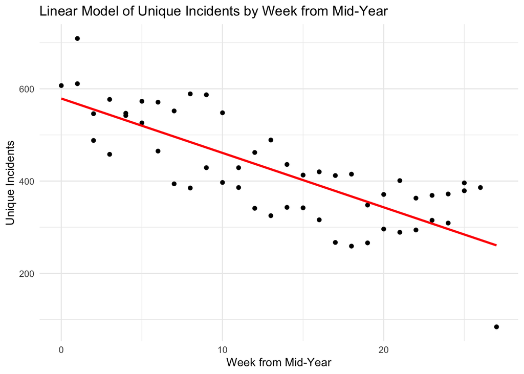

```r
# Plot the model
ggplot(df_by_week, aes(x = week_from_mid_year, y = unique_incidents)) +
  geom_point() +
  geom_smooth(method = "lm", se = FALSE, color = "red") +
  labs(
    title = "Linear Model of Unique Incidents by Week from Mid-Year",
    x = "Week from Mid-Year",
    y = "Unique Incidents"
  ) +
  theme_minimal()
```

We can see that the more far it is from summer the less incidents there are.

## Bias

### Bias from Data

Even by glance at the data we can see that there are many missing values.  
For some features, the majority of the values are missing.  
It does indicate that the data is not complete.

Another important aspect is that it is real-world data collected by the government.  
Thus, it can have hidden correlations and biases.  
E.g., some parts of the city are less covered by police and thus the number of incidents is lower.

### Personal Bias

The author of this report has been once in the US, namely in New York City.  
However, I just wandered around the city and did not have any experience with police or crime (which I am happy about, seeing the numbers now).  
Thus, I do not possess an understanding of the US life and culture.  
Neither the different locations in the city nor how the police work there.  
While, in a way, it protects me from being biased by my own experience.  
This limits my understanding of the domain, which is biased in itself.

## Conclusion

In this short report, we have studied the NYPD shooting incident data.  
The data was cleaned and transformed.  
The study was focused on time and space of the incidents, other features were skipped.  
It was found that there is a clear seasonality of the incidents.  
The safest is morning time in winter, while the most dangerous is midnight in summer.  
Modeling supported the findings.  
Geographically Staten Island is the safest borough, while Brooklyn is the most dangerous.  
However, data on population is required to support this claim.  
The bias of data and the author was discussed.

## P.S.

Thank you for reading this report.